# Exercise Movement Prediction

Justin Nafe

Sunday, April 19, 2015

# Executive Summary

This analysis predicts whether the user of accelerator is doing an exercise correctly or not. The column we are predicting is “classe”, which contains characters instead of continuous values, so the error measure or performance will be the accuracy of the predictions instead of the root mean square error (RMSE). We attempt to maximize the accuracy of the predictions.

All code to reproduce these results is within the projectAnalysis.Rmd file.

# Exploratory Analysis

I loaded in the training set and the test set, combined the two into one set keeping track of observations in the test set versus the training set. This allows me to convert numerical columns to factors and ensure that the training is aware of all possible factors in the case where factors in the test set are unknown in the training set. We did not have to worry about that in this analysis, but it makes the dataset easier to work with if I have to normalize a column.

The following is the summary of the training set. To save space, I only show summaries of the first 20 columns.

```
##        X              user_name      raw_timestamp_part_1
##  "Min.   :    1  " "adelmo  :3892  " "Min.   :1.322e+09  "
##  "1st Qu.: 4906  " "carlitos:3112  " "1st Qu.:1.323e+09  "
##  "Median : 9812  " "charles :3536  " "Median :1.323e+09  "
##  "Mean   : 9812  " "eurico  :3070  " "Mean   :1.323e+09  "
##  "3rd Qu.:14717  " "jeremy  :3402  " "3rd Qu.:1.323e+09  "
##  "Max.   :19622  " "pedro   :2610  " "Max.   :1.323e+09  "
##  NA                NA                NA
##  raw_timestamp_part_2          cvtd_timestamp    new_window
##  "Min.   :   294  "   "28/11/2011 14:14: 1498  " "no :19216  "
##  "1st Qu.:252912  "   "05/12/2011 11:24: 1497  " "yes:  406  "
##  "Median :496380  "   "30/11/2011 17:11: 1440  " NA
##  "Mean   :500656  "   "05/12/2011 11:25: 1425  " NA
##  "3rd Qu.:751891  "   "02/12/2011 14:57: 1380  " NA
##  "Max.   :998801  "   "02/12/2011 13:34: 1375  " NA
##  NA                   "(Other)         :11007  " NA
##    num_window        roll_belt          pitch_belt
##  "Min.   :  1.0  " "Min.   :-28.90  " "Min.   :-55.8000  "
##  "1st Qu.:222.0  " "1st Qu.:  1.10  " "1st Qu.:  1.7600  "
##  "Median :424.0  " "Median :113.00  " "Median :  5.2800  "
##  "Mean   :430.6  " "Mean   : 64.41  " "Mean   :  0.3053  "
##  "3rd Qu.:644.0  " "3rd Qu.:123.00  " "3rd Qu.: 14.9000  "
##  "Max.   :864.0  " "Max.   :162.00  " "Max.   : 60.3000  "
##  NA                NA                 NA
##     yaw_belt         total_accel_belt  kurtosis_roll_belt
##  "Min.   :-180.00  " "Min.   : 0.00  " "         :19216  "
##  "1st Qu.: -88.30  " "1st Qu.: 3.00  " "#DIV/0!  :   10  "
##  "Median : -13.00  " "Median :17.00  " "-1.908453:    2  "
##  "Mean   : -11.21  " "Mean   :11.31  " "-0.016850:    1  "
##  "3rd Qu.:  12.90  " "3rd Qu.:18.00  " "-0.021024:    1  "
##  "Max.   : 179.00  " "Max.   :29.00  " "-0.025513:    1  "
##  NA                  NA                "(Other)  :  391  "
##  kurtosis_picth_belt kurtosis_yaw_belt skewness_roll_belt
##  "         :19216  " "       :19216  " "         :19216  "
##  "#DIV/0!  :   32  " "#DIV/0!:  406  " "#DIV/0!  :    9  "
##  "47.000000:    4  " NA                "0.000000 :    4  "
##  "-0.150950:    3  " NA                "0.422463 :    2  "
##  "-0.684748:    3  " NA                "-0.003095:    1  "
##  "-1.750749:    3  " NA                "-0.010002:    1  "
##  "(Other)  :  361  " NA                "(Other)  :  389  "
##  skewness_roll_belt.1 skewness_yaw_belt max_roll_belt
##  "         :19216  "  "       :19216  " "Min.   :-94.300  "
##  "#DIV/0!  :   32  "  "#DIV/0!:  406  " "1st Qu.:-88.000  "
##  "0.000000 :    4  "  NA                "Median : -5.100  "
##  "-2.156553:    3  "  NA                "Mean   : -6.667  "
##  "-3.072669:    3  "  NA                "3rd Qu.: 18.500  "
##  "-6.324555:    3  "  NA                "Max.   :180.000  "
##  "(Other)  :  361  "  NA                "NA's   :19216  "
##  max_picth_belt     max_yaw_belt
##  "Min.   : 3.00  " "       :19216  "
##  "1st Qu.: 5.00  " "-1.1   :   30  "
##  "Median :18.00  " "-1.4   :   29  "
##  "Mean   :12.92  " "-1.2   :   26  "
##  "3rd Qu.:19.00  " "-0.9   :   24  "
##  "Max.   :30.00  " "-1.3   :   22  "
##  "NA's   :19216  " "(Other):  275  "
```

The summary shows a lot of room for cleanup with divide by zero, `NA` values, and blank values. There are so many `NA` values in the columns starting with “std”, “var”, etc… because those columns are meant to summarize the exercise window. The summary data is collected when one window ends and a new one begins, or when the “new_window” column contains “yes”.

Looks like those values are set when the window is new = “yes”

I am going to assume that the columns starting with “avg”, “std”, “var”, “max”, “min”, “kurtosis”, “skewness” are useless for our prediction. I will remove columns that have a high rate of `NA` or blank values.

```r
getColumnsWithHighUnknown <- function(dataset, thresh){
  results <- 1:dim(dataset)[2]
  nrows <- dim(dataset)[1]
  for(i in 1:dim(dataset)[2]){
    nas <- sum(is.na(dataset[,i]))
    blanks <- sum(dataset[,i] == "")

    if((nas/nrows >= thresh || blanks/nrows >= thresh)){
      results[i] <- i
    }
    else{
      results[i] <- 0
    }
  }
  results <- results[results > 0]
  results
}
removeCols <- getColumnsWithHighUnknown(train, 0.5)
fullset <- fullset[,-removeCols]

summary(fullset)[,1:20]
```

```
##        X              user_name      raw_timestamp_part_1
##  "Min.   :    1  " "adelmo  :3893  " "Min.   :1.322e+09  "
##  "1st Qu.: 4891  " "carlitos:3115  " "1st Qu.:1.323e+09  "
##  "Median : 9802  " "charles :3537  " "Median :1.323e+09  "
##  "Mean   : 9802  " "eurico  :3074  " "Mean   :1.323e+09  "
##  "3rd Qu.:14712  " "jeremy  :3410  " "3rd Qu.:1.323e+09  "
##  "Max.   :19622  " "pedro   :2613  " "Max.   :1.323e+09  "
##  NA                NA                NA
##  raw_timestamp_part_2          cvtd_timestamp    new_window
##  "Min.   :   294  "   "05/12/2011 11:24: 1500  " "no :19236  "
##  "1st Qu.:252912  "   "28/11/2011 14:14: 1500  " "yes:  406  "
##  "Median :496387  "   "30/11/2011 17:11: 1444  " NA
##  "Mean   :500668  "   "05/12/2011 11:25: 1425  " NA
##  "3rd Qu.:752270  "   "02/12/2011 14:57: 1381  " NA
##  "Max.   :998801  "   "02/12/2011 13:34: 1375  " NA
##  NA                   "(Other)         :11017  " NA
##    num_window        roll_belt          pitch_belt
##  "Min.   :  1.0  " "Min.   :-28.90  " "Min.   :-55.8000  "
##  "1st Qu.:222.0  " "1st Qu.:  1.10  " "1st Qu.:  1.7625  "
##  "Median :424.0  " "Median :113.00  " "Median :  5.2800  "
##  "Mean   :430.6  " "Mean   : 64.37  " "Mean   :  0.3109  "
##  "3rd Qu.:644.0  " "3rd Qu.:123.00  " "3rd Qu.: 14.9000  "
##  "Max.   :864.0  " "Max.   :162.00  " "Max.   : 60.3000  "
##  NA                NA                 NA
##     yaw_belt         total_accel_belt   gyros_belt_x
##  "Min.   :-180.00  " "Min.   : 0.00  " "Min.   :-1.040000  "
##  "1st Qu.: -88.30  " "1st Qu.: 3.00  " "1st Qu.:-0.030000  "
##  "Median : -13.10  " "Median :17.00  " "Median : 0.030000  "
##  "Mean   : -11.25  " "Mean   :11.31  " "Mean   :-0.005632  "
##  "3rd Qu.:  12.80  " "3rd Qu.:18.00  " "3rd Qu.: 0.110000  "
##  "Max.   : 179.00  " "Max.   :29.00  " "Max.   : 2.220000  "
##  NA                  NA                NA
##   gyros_belt_y         gyros_belt_z        accel_belt_x
##  "Min.   :-0.64000  " "Min.   :-1.4600  " "Min.   :-120.000  "
##  "1st Qu.: 0.00000  " "1st Qu.:-0.2000  " "1st Qu.: -21.000  "
##  "Median : 0.02000  " "Median :-0.1000  " "Median : -15.000  "
##  "Mean   : 0.03956  " "Mean   :-0.1305  " "Mean   :  -5.603  "
##  "3rd Qu.: 0.11000  " "3rd Qu.:-0.0200  " "3rd Qu.:  -5.000  "
##  "Max.   : 0.64000  " "Max.   : 1.6200  " "Max.   :  85.000  "
##  NA                   NA                  NA
##   accel_belt_y       accel_belt_z       magnet_belt_x
##  "Min.   :-69.00  " "Min.   :-275.00  " "Min.   :-52.00  "
##  "1st Qu.:  3.00  " "1st Qu.:-162.00  " "1st Qu.:  9.00  "
##  "Median : 34.00  " "Median :-152.00  " "Median : 35.00  "
##  "Mean   : 30.14  " "Mean   : -72.54  " "Mean   : 55.58  "
##  "3rd Qu.: 61.00  " "3rd Qu.:  27.00  " "3rd Qu.: 59.00  "
##  "Max.   :164.00  " "Max.   : 105.00  " "Max.   :485.00  "
##  NA                 NA                  NA
##  magnet_belt_y     magnet_belt_z
##  "Min.   :354.0  " "Min.   :-623.0  "
##  "1st Qu.:581.0  " "1st Qu.:-375.0  "
##  "Median :601.0  " "Median :-320.0  "
##  "Mean   :593.7  " "Mean   :-345.5  "
##  "3rd Qu.:610.0  " "3rd Qu.:-306.0  "
##  "Max.   :673.0  " "Max.   : 293.0  "
##  NA                NA
```

Removing the summary data seemed to get rid of all the `NA` values.

I’ll start the cleanup by seeing what columns if any won’t contribute to the prediction by using nearZeroVar for numerical columns

```r
getNumericColumns <- function(dataset){
  results <- 1:dim(dataset)[2]
  for(i in 1:dim(dataset)[2]){
    if(class(dataset[,i]) == "integer" || class(dataset[,i]) == "numeric"){
      results[i] <- i
    }
    else{
      results[i] <- 0
    }
  }
  results <- results[results > 0]
  results
}
numericCols <- getNumericColumns(fullset)
temp <- nearZeroVar(fullset[1:n.train,numericCols])
temp
```

```
## integer(0)
```

No numeric columns have a near zero variance after having removed the columns high in `NA`’s.

For factor columns, let us see if the factors contribute to the prediction. We will look at the New Window and User Name columns.

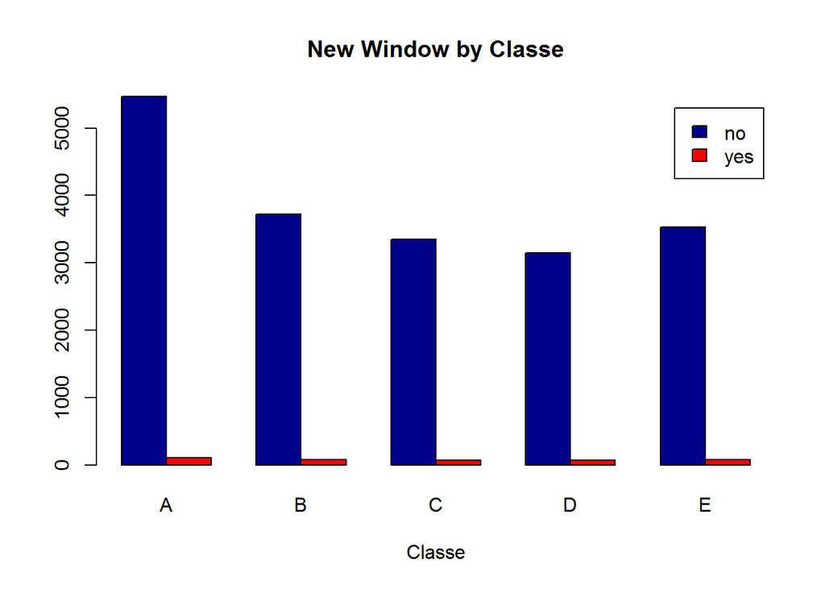

```r
temp <- fullset[1:n.train,]
counts <- table(temp$new_window, temp$classe)
barplot(counts, main="New Window by Classe",
  xlab="Classe", col=c("darkblue","red"),
   legend = rownames(counts), beside=TRUE)
```

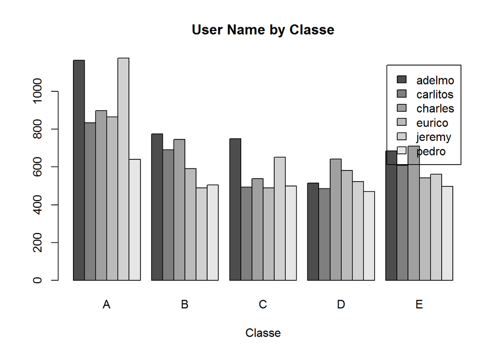

```r
counts <- table(temp$user_name, temp$classe)
barplot(counts, main="User Name by Classe",
  xlab="Classe",
   legend = rownames(counts), beside=TRUE)
```

```r
fullset <- fullset[,-grep("new_window", colnames(fullset))]
```

The factor columns provides some variance, so they may contribute. I used trial and error removing one at a time and the combinations to increase accuracy. I maximized accuracy with cross validation removing New Window and leaving in User Name.

# Model

Let’s build the model that will be used to predict the classe. We will normalize and reduce skewness of the numeric data using “center” and “scale” settings and use Principle Component Analysis (PCA) for the reduction of features by combining highly correlated features so as to not lose any information.

Random forest does a form or cross validation with resampling int he process of building the tree. Instead of the default resampling method of cross validation, I use fold to see how the Accuracy varies. Using the default cross validation of resampling, the Accuracy was lower than using folds.

```r
set.seed(8947)
tgrid <- expand.grid(mtry=c(2))
model <- train(classe~.,
               data=fullset[1:n.train,-1],
               preProcess = c("center", "scale", "pca"),
               method = "rf",
               trControl = trainControl(method = "cv", number = 50),
               tuneGrid = tgrid)
model
```

```
## Random Forest
##
## 19622 samples
##    57 predictor
##     5 classes: 'A', 'B', 'C', 'D', 'E'
##
## Pre-processing: centered, scaled, principal component signal extraction
## Resampling: Cross-Validated (50 fold)
##
## Summary of sample sizes: 19230, 19231, 19231, 19231, 19228, 19230, ...
##
## Resampling results
##
##   Accuracy   Kappa      Accuracy SD  Kappa SD
##   0.9898075  0.9871063  0.004938607  0.006247149
##
## Tuning parameter 'mtry' was held constant at a value of 2
##
```

Using “cv” for cross validation, with a higher number of folds (50) for the large number of features, yielded an Accuracy 0.99 for the “out of sample” estimate.

# Prediction

Using the model we created in the previous section, we predict the “classe” of the test set.

```r
prediction <- predict(model, fullset[-c(1:n.train), -1])
```

For each problem in the test set, this model predicts the following:

```
##    Problem Result
## 1        1      B
## 2        2      A
## 3        3      C
## 4        4      A
## 5        5      A
## 6        6      E
## 7        7      D
## 8        8      B
## 9        9      A
## 10      10      A
## 11      11      B
## 12      12      C
## 13      13      B
## 14      14      A
## 15      15      E
## 16      16      E
## 17      17      A
## 18      18      B
## 19      19      B
## 20      20      B
```